# Basic testing of nonlinear model approach for total biomass

Alice Stears

2025-08-07

Load packages and data

```r
# load packages -----------------------------------------------------------
library(tidyverse)
library(gnm)
library(terra)
library(tidyterra)
library(patchwork)
# load data ---------------------------------------------------------------

dat <- readRDS("/Users/astears/Documents/Dropbox_static/Work/NAU_USGS_postdoc/PED_vegClimModels/Data_processed/BiomassQuantityData/GEDIbiomass_predictedCover_climateAndSoils.rds")

# make min. biomass value not 0
dat[dat$totalBiomass_MgHect == 0 & !is.na(dat$totalBiomass_MgHect), "totalBiomass_MgHect"] <-
  dat[dat$totalBiomass_MgHect == 0 & !is.na(dat$totalBiomass_MgHect), "totalBiomass_MgHect"] + .001

# # try transforming the model response
#  dat[, "totalBiomass_MgHect"] + 2

# scale the predictors
name_lookup <- c(
  tmean_s = "tmean",
  prcpTempCorr_s = "prcpTempCorr",
  isothermality_s = "isothermality",
  annWatDef_s ="annWatDef",
  prcp_s = "prcp",
  prcp_seasonality_s = "prcp_seasonality",
  prcp_dry_s = "prcp_dry",
  annWetDegDays_s = "annWetDegDays",
  t_warm_s = "t_warm",
  t_cold_s = "t_cold",
  prcp_wet_s = "prcp_wet",
  soilDepth_s = "soilDepth",
  sand_s = "sand",
  coarse_s = "coarse",
  AWHC_s = "AWHC",
  clay_s = "clay",
  carbon_s = "carbon")

dat_scaled <- dat %>%
  select(tmean, prcpTempCorr, isothermality, annWatDef,
         prcp, prcp_seasonality, prcp_dry, annWetDegDays,
         t_warm, t_cold, prcp_wet, soilDepth, sand, coarse, AWHC, clay, carbon) %>%
  dplyr::rename(all_of(name_lookup)) %>%
  scale()

dat <- dat %>%
  cbind(dat_scaled) %>%
  #select(1:40,43:65) %>%
  mutate(shrubCover = broadLeavedTreeCover + needleLeavedTreeCover, # calculate total tree and herbaceous cover
         shrubCover = C3GramCover + C4GramCover + forbCover)
```

(From Daniel): ” What we ultimately want from these models is information about this relationship like this: $biomass(type_i, pixel_j) \sim predictors_{ij}$

However, we don’t have $biomass(type_i, .)$; we do have $totalBiomass$ and $cover(type_i, .)$. Even though the relationship between cover and biomass is not ideal at high cover value as we have discussed a little while ago, it may be what is available to us. This would look like: $biomass(type_i, pixel_j) \sim biomassTotal(pixel_j) * allometricFraction(type_i, cover_i)$

Instead of scouring the literature for such biomass ~ cover relationships for each of our 6 types, how would it work if we fit that relationship in the same model fitting as biomass ~ predictors? Along the lines of: $biomassTotal(pixel_j) * allometricFraction(type_i, cover_i) \sim predictors_{ij}$

We probably want a saturating relationship for allometricFraction(), potentially as simple as $allometricFraction(type_i, cover) \sim a_i * cover / (b_i + cover)$

Potentially, we could consider separate relationships for the non-tree types in the presence of trees (or simply in our “forest” ecoregion) to separate out understory conditions from “real” grasslands/shrublands. ”

Rewritten, this equation is $biomassTotal(pixel_j) \sim predictors_{ij} *1/(a_i * cover / (b_i + cover))$

To model this, we need to use a non-linear approach because of the nonlinear transformation of cover. Below is a basic attempt to fit a model using shrubCover and scaled climate and soils predictors. Because the response variable, biomass, is distributed between (0,Inf), I used a Gamma distribution with a log link as the model family. I also used the gnm R package.

```r
# specify model with gnm --------------------------------------------------
#μ=(β 1⋅climate+β2⋅soils)⋅f(cover;β3,β4)
# Here, climate and soils have linear effects (beta1, beta2) while beta3, beta4 are estimated through Nonlin().
# get data for tree cover, just for forest ecoregions
dat_shrub <- dat %>%
  filter(newRegion %in% c("eastForest", "westForest")) %>% #c("dryShrubGrass")) %>% #c("eastForest", "westForest")) %>%
  select(totalBiomass_MgHect, shrubCover, tmean_s, prcpTempCorr_s, isothermality_s, annWatDef_s,
         prcp_s, prcp_seasonality_s, prcp_dry_s, annWetDegDays_s,
         t_warm_s, t_cold_s, prcp_wet_s, soilDepth_s, sand_s, coarse_s,
         AWHC_s, clay_s, carbon_s, x, y, newRegion) %>%
  drop_na()
# make sure that shrub cover is > 0
dat_shrub[dat_shrub$shrubCover==0, "shrubCover"]
```

```
## numeric(0)
```

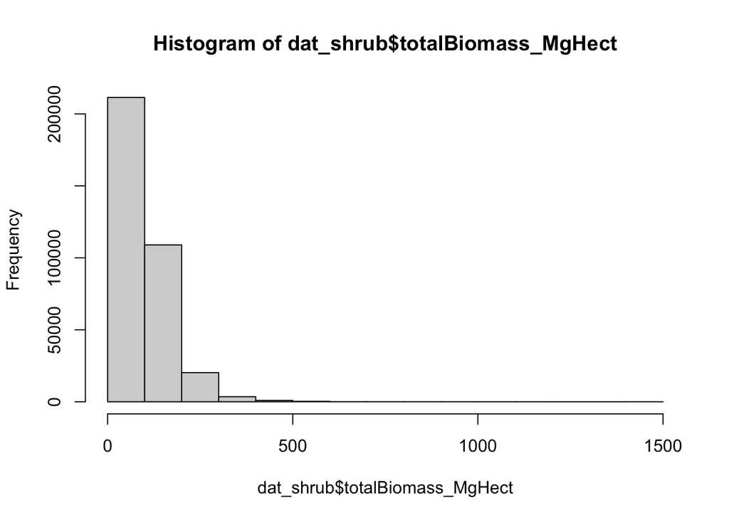

```r
# make sure that total biomass isn't 0
dat_shrub[dat_shrub$totalBiomass_MgHect == 0, "totalBiomass_MgHect"] <-
dat_shrub[dat_shrub$totalBiomass_MgHect == 0, "totalBiomass_MgHect"] + .00001

# do a log transformation of the response
# dat_shrub <- dat_shrub %>%
#   mutate(totalBiomass_MgHect_logPlusConstant = log(totalBiomass_MgHect + 4))

# use a transformation of total biomass so the gamma model will fit
dat_shrub[, "totalBiomass_MgHect"] <- dat_shrub[, "totalBiomass_MgHect"] + 2

hist(dat_shrub$totalBiomass_MgHect)
```

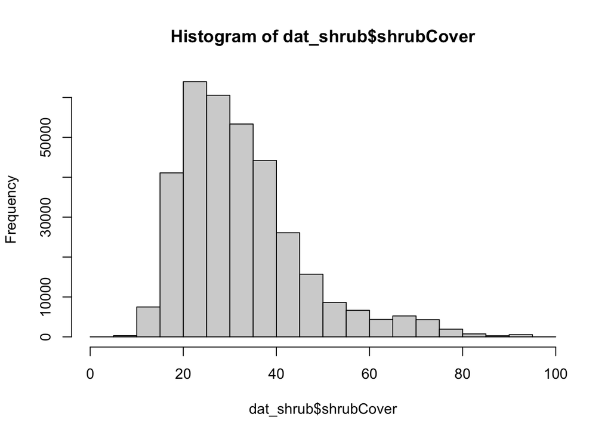

```r
hist(dat_shrub$shrubCover)
```

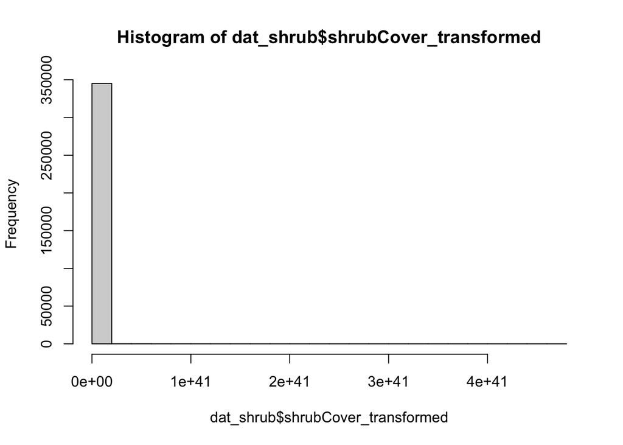

```r
## pre-calculate non-linear, sigmoid term for allometric fraction
dat_shrub$shrubCover_transformed <- exp(dat_shrub$shrubCover)#1/(1 + exp(-1 * dat_shrub$shrubCover))
hist(dat_shrub$shrubCover_transformed)
```

```r
## use glm to get starting values for the gnm
glm_fit <- glm(totalBiomass_MgHect ~ tmean_s + prcpTempCorr_s +  isothermality_s + annWatDef_s + prcp_s +
                 prcp_seasonality_s + prcp_dry_s + annWetDegDays_s + t_warm_s + t_cold_s + prcp_wet_s + soilDepth_s +
                 sand_s + coarse_s + AWHC_s + clay_s + carbon_s + offset(1/(1 + exp(- shrubCover))),#
               data = dat_shrub,
               family = Gamma(link = "log"))
# Then use coef(glm_fit) to initialize beta_j (for the linear terms) in your gnm start vector.

## re-write the nonlinear term (1/(1 + exp(-x))) to be exp(x)/1+exp(x) so that the model actually fits

fit_gnm <- gnm(totalBiomass_MgHect ~ gnm::Mult(tmean_s + prcpTempCorr_s +  isothermality_s + annWatDef_s +
                                                 prcp_s + prcp_seasonality_s + prcp_dry_s + annWetDegDays_s +
                                                 t_warm_s + t_cold_s + prcp_wet_s + soilDepth_s + sand_s +
                                                 coarse_s + AWHC_s + clay_s + carbon_s,
                                               shrubCover_transformed, gnm::Inv(1 + shrubCover_transformed)),
               #gnm::Inv(shrubCover), (1 + offset(shrubCover))
               method = "gnmFit",
               start = c(coef(glm_fit)[1:18], 1, 1, 1),
               data = dat_shrub,
               family = Gamma(link = "log"),
               iterMax = 2000
)
```

```
## Running main iterations........................
## Done
```

```r
#summary(fit_gnm)
```

See how the allometric fraction term looks with fitted coefficients

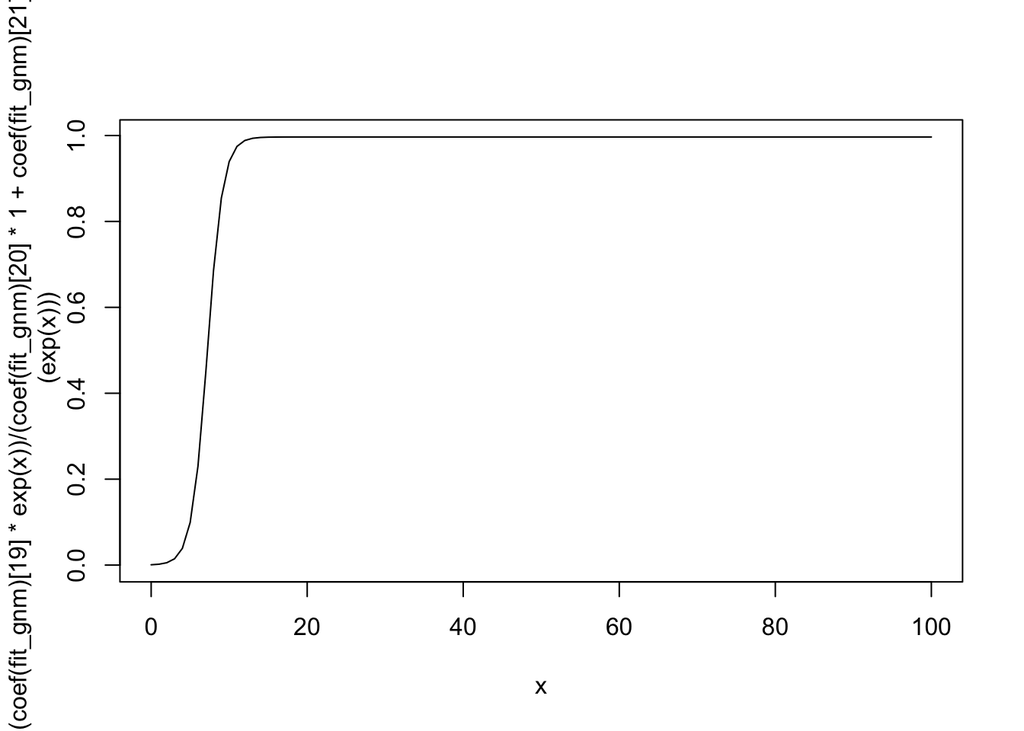

```r
curve((coef(fit_gnm)[19] * exp(x))/(coef(fit_gnm)[20]*1 + coef(fit_gnm)[21]*(exp(x))),

  #coef(fit_gnm)[19]*1/(1+exp(-x)),#(.99 * x) / (coef(fit_gnm)[20] + x),
  from = 0, to = 100)
```

Here are predictions from this model using synthetic shrub cover data and mean values for each scaled climate and soils predictor:

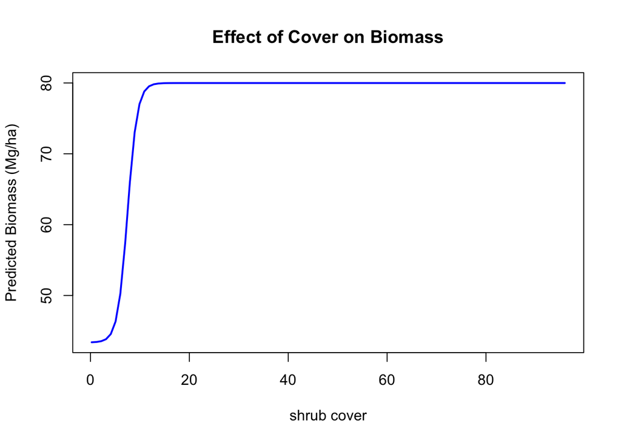

```r
# Predict using this model ------------------------------------------------
# Generate a sequence of cover values across observed range
cover_seq <- seq(min(dat_shrub$shrubCover, na.rm = TRUE),
                 max(dat_shrub$shrubCover, na.rm = TRUE),
                 length.out = 100)

# Create a new data frame for prediction
new_data <- data.frame(
  shrubCover = cover_seq,
  shrubCover_transformed = exp(cover_seq),
  tmean_s = mean(dat_shrub$tmean_s, na.rm = TRUE),
  prcpTempCorr_s = mean(dat_shrub$prcpTempCorr_s, na.rm = TRUE),
  isothermality_s = mean(dat_shrub$isothermality_s, na.rm = TRUE),
  annWatDef_s = mean(dat_shrub$annWatDef_s, na.rm = TRUE),
  prcp_s = mean(dat_shrub$prcp_s, na.rm = TRUE),
  prcp_seasonality_s = mean(dat_shrub$prcp_seasonality_s, na.rm = TRUE),
  prcp_dry_s = mean(dat_shrub$prcp_dry_s, na.rm = TRUE),
  annWetDegDays_s = mean(dat_shrub$annWetDegDays_s, na.rm = TRUE),
  t_warm_s = mean(dat_shrub$t_warm_s, na.rm = TRUE),
  t_cold_s = mean(dat_shrub$t_cold_s, na.rm = TRUE),
  prcp_wet_s = mean(dat_shrub$prcp_wet_s, na.rm = TRUE),
  soilDepth_s= mean(dat_shrub$soilDepth_s, na.rm = TRUE),
  sand_s = mean(dat_shrub$sand_s, na.rm = TRUE),
  coarse_s = mean(dat_shrub$coarse_s, na.rm = TRUE),
  AWHC_s = mean(dat_shrub$AWHC_s, na.rm = TRUE),
  clay_s = mean(dat_shrub$clay_s, na.rm = TRUE),
  carbon_s = mean(dat_shrub$carbon_s, na.rm = TRUE)
)

# Predict biomass on the response scale
new_data$predicted_biomass <- predict(fit_gnm, newdata = new_data, type = "response") - 2

# 5. Plot the predictions

plot(
  new_data$shrubCover,
  new_data$predicted_biomass,
  type = "l",
  lwd = 2,
  col = "blue",
  xlab = "shrub cover",
  ylab = "Predicted Biomass (Mg/ha)",
  main = "Effect of Cover on Biomass"
)
```

Here are maps of the raw biomass data, modeled shrub cover data, as well as the predicted biomass and the residuals (observed biomass vs. predicted biomass)

```r
# plot the predictions and residuals --------------------------------------
# rasterize the biomass and shrub cover data
test_rast <-  rast("/Users/astears/Documents/Dropbox_static/Work/NAU_USGS_postdoc/PED_vegClimModels/Data_raw/dayMet/rawMonthlyData/orders/70e0da02b9d2d6e8faa8c97d211f3546/Daymet_Monthly_V4R1/data/daymet_v4_prcp_monttl_na_1980.tif")
# rasterize total biomass in Mg/hect
dat_biomass_rast <- dat %>%
  terra::vect(geom = c("x", "y"), crs = crs(test_rast)) %>%
  terra::rasterize(test_rast, field = "totalBiomass_MgHect") %>%
  terra::aggregate(fun = "mean", na.rm = TRUE, fact = 8)
```

```
## |---------|---------|---------|---------|=========================================
```

```r
# rasterize % shrub cover
dat_shrubCover_rast <- dat %>%
  terra::vect(geom = c("x", "y"), crs = crs(test_rast)) %>%
  terra::rasterize(test_rast, field = "shrubCover") %>%
  terra::aggregate(fun = "mean", na.rm = TRUE, fact = 8)
```

```
## |---------|---------|---------|---------|=========================================
```

```r
# generate predictions for this model using training data
# the 'shrub cover' term is called "shrubCover_term" in the dat_shrub data.frame
# Predict biomass on the response scale
dat_shrub$predicted_totalBiomass <- predict(fit_gnm, newdata = dat_shrub, type = "response") - 2
# rasterize predicted total biomass in Mg/hect
dat_biomassPreds_rast <- dat_shrub %>%
  terra::vect(geom = c("x", "y"), crs = crs(test_rast)) %>%
  terra::rasterize(test_rast, field = "predicted_totalBiomass") %>%
  terra::aggregate(fun = "mean", na.rm = TRUE, fact = 8)
```

```
## |---------|---------|---------|---------|=========================================
```

```r
## calculate the residuals
dat_resids_rast <- (dat_biomass_rast - dat_biomassPreds_rast)/dat_biomass_rast * 100

## calculate the model predicted biomass for the target functional group
dat_funcGroupBiomassPred <- dat_biomassPreds_rast *coef(fit_gnm)[19]*1/(1+exp(-dat_shrubCover_rast)) #(.99 * dat_shrubCover_rast) / (coef(fit_gnm)[20] + dat_shrubCover_rast)

# make plots
plot_biomass <- ggplot() +
  geom_spatraster(data = dat_biomass_rast) +
  labs(title = paste0("Observed total biomass from GEDI; Mg/hect")) +
  scale_fill_gradient2(low = "white",
                       high = "purple" ,
                       limits = c(0,1500),  na.value = "lightgrey") +
  xlim(c(-2060750, 2555250)) +
  ylim(c(-1895500, 972500))
```

```
## <SpatRaster> resampled to 500424 cells.
```

```r
dat_biomassPreds_big <- dat_biomassPreds_rast %>%
  terra::mask(mask = ifel(. > 1500, 1, NA)) %>%
  terra::as.points()

plot_biomassPreds <- ggplot() +
    geom_spatraster(data = dat_biomassPreds_rast) +
  geom_spatvector(data = dat_biomassPreds_big, col = "darkorchid") +
    labs(title = paste0("Predicted total biomass from model; Mg/hect"),
         subtite = "Points indicate locations where predicted biomass is > 2000") +
    scale_fill_gradient2(low = "white",
                         high = "purple" ,
                         limits = c(0,1500),  na.value = "lightgrey") +
    xlim(c(-2060750, 2555250)) +
    ylim(c(-1895500, 972500))
```

```
## <SpatRaster> resampled to 500424 cells.
```

```r
# points where values are >500 or < -500
dat_resids_big <- dat_resids_rast %>%
  terra::mask(mask = ifel(. > 500, 1, NA)) %>%
  terra::as.points()
dat_resids_small <- dat_resids_rast %>%
  terra::mask(mask = ifel(. < -500, 1, NA)) %>%
  terra::as.points()
plot_biomassResids <- ggplot() +
    geom_spatraster(data = dat_resids_rast) +
    geom_spatvector(data = dat_resids_big, col = "red") +
    geom_spatvector(data = dat_resids_small, col = "blue") +
    labs(title = paste0("Residuals of biomass predictions as percentage of observed (obs - pred)/obs * 100"),
         subtitle = "points show locations where residuals are > 500 (red) or < -500 (blue)") +
    scale_fill_gradient2(low = "blue",
                         high = "red" ,
                         limits = c(-500,500),  na.value = "lightgrey") +
    xlim(c(-2060750, 2555250)) +
    ylim(c(-1895500, 972500))
```

```
## <SpatRaster> resampled to 500424 cells.
```

```r
# plot of herbaceous cover
plot_shrubCover <- ggplot() +
    geom_spatraster(data = dat_shrubCover_rast) +
    labs(title = paste0("Modeled shrub cover")) +
    scale_fill_gradient2(low = "white",
                         high = "forestgreen" ,
                         limits = c(0,100),  na.value = "lightgrey") +
    xlim(c(-2060750, 2555250)) +
    ylim(c(-1895500, 972500))
```

```
## <SpatRaster> resampled to 500424 cells.
```

```r
# plot of target functional group biomass
plot_funcGroupBiomassPred <- ggplot() +
    geom_spatraster(data = dat_funcGroupBiomassPred) +
    labs(title = paste0("Predicted biomass from model for func. group of interest; Mg/hect"),
         subtite = "Points indicate locations where predicted biomass is > 2000") +
    scale_fill_gradient2(low = "white",
                         high = "orange" ,
                         #limits = c(0,2000),
                         na.value = "lightgrey") +
    xlim(c(-2060750, 2555250)) +
    ylim(c(-1895500, 972500))
```

```
## <SpatRaster> resampled to 500424 cells.
```

```r
# make plot w/ RAP data for total herbaceous
RAPdat <- terra::rast("/Users/astears/Documents/Dropbox_static/Work/NAU_USGS_postdoc/PED_vegClimModels/Data_processed/BiomassQuantityData/RAP_biomassRaster_totalHerb_Mg_Hect_averagedfrom2019to2021.tif")
RAPdat <- RAPdat %>%
  terra::resample(y = dat_funcGroupBiomassPred)

# plot
plot_RAPbiomass <- ggplot() +
    geom_spatraster(data = RAPdat) +
    labs(title = paste0("Herbaceous biomass from RAP; Mg/hect")) +
    scale_fill_gradient2(low = "white",
                         high = "orange" ,
                         #limits = c(0,2000),
                         na.value = "lightgrey") +
    xlim(c(-2060750, 2555250)) +
    ylim(c(-1895500, 972500))
```

```
## <SpatRaster> resampled to 500424 cells.
```

```r
# plot resids between model predictions and RAP
dat_residsFromRap_rast <- (RAPdat - dat_funcGroupBiomassPred)/RAPdat * 100

# points where values are >500 or < -500
dat_residsFromRap_big <- dat_residsFromRap_rast %>%
  terra::mask(mask = ifel(. > 500, 1, NA)) %>%
  terra::as.points()
dat_residsFromRap_small <- dat_residsFromRap_rast %>%
  terra::mask(mask = ifel(. < -500, 1, NA)) %>%
  terra::as.points()
plot_biomassResidsFromRap <- ggplot() +
    geom_spatraster(data = dat_residsFromRap_rast) +
    geom_spatvector(data = dat_residsFromRap_big, col = "red") +
    geom_spatvector(data = dat_residsFromRap_small, col = "blue") +
    labs(title = paste0("Residuals of biomass predictions as percentage of observed (obs - pred)/obs * 100"),
         subtitle = "points show locations where residuals are > 500 (red) or < -500 (blue)") +
    scale_fill_gradient2(low = "blue",
                         high = "red" ,
                         limits = c(-500,500),  na.value = "lightgrey") +
    xlim(c(-2060750, 2555250)) +
    ylim(c(-1895500, 972500))
```

```
## <SpatRaster> resampled to 500424 cells.
```

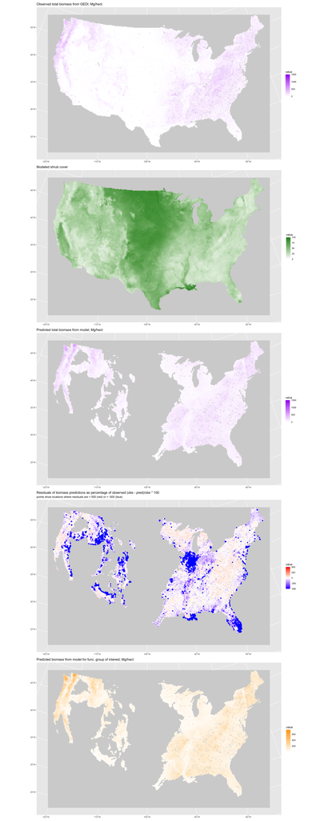

```r
(plot_biomass ) /  plot_shrubCover/ (plot_biomassPreds )/plot_biomassResids/plot_funcGroupBiomassPred#/ plot_RAPbiomass / #lot_biomassResidsFromRap
```